# Regresja liniowa

7 stycznia 2019

# Rozgrzewka (10 minut)

Zbiór api zawiera wyniki testu kompetencji przeprowadzonego wśród uczniów w Kalifornii. Dokładny opis zmiennych znajduje się w pliku pomocy. Nas interesują dzisiaj trzy z nich:

- ell - English Language Learners
- enroll - number of students enrolled
- api.stu - number of students tested

```r
library(tidyverse)
library(survey)
data(api)

# próba
schemat <- svydesign(id=~1, strata=~stype, weights=~pw, data=apistrat, fpc=~fpc)
```

Liczba studentów biorących udział w badaniu w populacji

```r
sum(apipop$api.stu)
```

```
## [1] 3196602
```

1. Na podstawie próby oszacuj liczbę osób biorących udział w teście (api.stu).

```r
svytotal(x = ~api.stu, design = schemat)
```

```
##           total    SE
## api.stu 3086009 99477
```

2. Na podstawie próby oszacuj jaki odsetek wziął udział w teście (api.stu/enroll)

```r
svyratio(numerator = ~api.stu, denominator = ~enroll, design = schemat)
```

```
## Ratio estimator: svyratio.survey.design2(numerator = ~api.stu, denominator = ~enroll,
##     design = schemat)
## Ratios=
##            enroll
## api.stu 0.8369569
## SEs=
##              enroll
## api.stu 0.007757103
```

# Regresja liniowa

## Bez wyrazu wolnego

Oszacowanie wartości globalnej liczby osób biorących udział w teście na podstawie wartości wskaźnika

```r
r1 <- svyratio(numerator = ~api.stu, denominator = ~enroll, design = schemat)

predict(r1, total = sum(apipop$enroll, na.rm = T))
```

```
## $total
##          enroll
## api.stu 3190038
##
## $se
##           enroll
## api.stu 29565.98
```

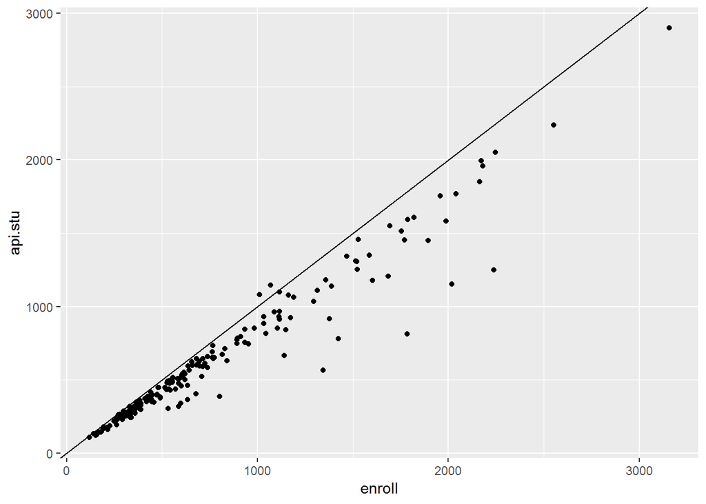

```r
ggplot(apistrat, aes(enroll, api.stu)) +
  geom_point() +
  geom_abline(intercept = 0)
```

### Zadanie (10 minut)

Proszę powtórzyć powyższy tok obliczeń dla zmiennej English Language Learners (ell):

- na podstawie próby oszacować wartość globalną
- na podstawie próby oszacować wskaźnik (ell/enroll)
- na podstawie wskaźnika oszacować wartość globalną

Co się dzieje z precyzją estymacji? Narysuj wykres - wskaże przyczynę takiego stanu rzeczy.

```r
svytotal(x = ~ell, schemat)
```

```
##      total    SE
## ell 141618 10376
```

```r
r2 <- svyratio(numerator = ~ell, denominator = ~enroll, schemat)
r2
```

```
## Ratio estimator: svyratio.survey.design2(numerator = ~ell, denominator = ~enroll,
##     schemat)
## Ratios=
##         enroll
## ell 0.03840811
## SEs=
##          enroll
## ell 0.002791403
```

```r
predict(r2, total = sum(apipop$enroll, na.rm = T))
```

```
## $total
##       enroll
## ell 146391.5
##
## $se
##       enroll
## ell 10639.36
```

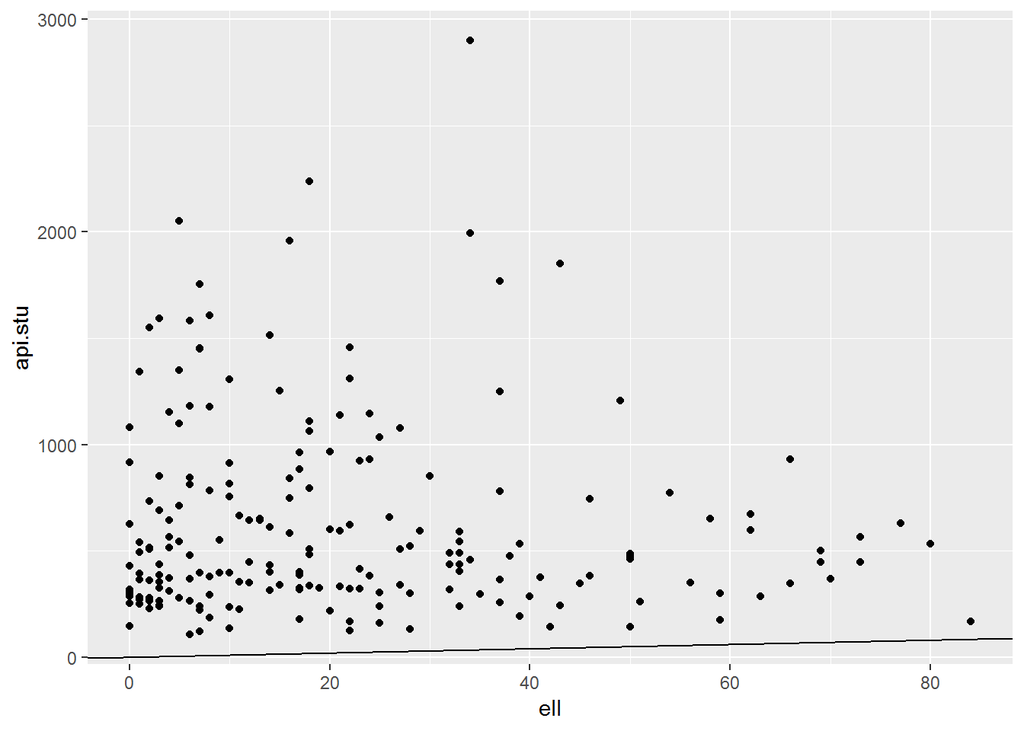

```r
ggplot(apistrat, aes(ell, api.stu)) +
  geom_point() +
  geom_abline(intercept = 0)
```

## Uwzględnienie wag z próby w regresji liniowej

Mamy 5 punktów

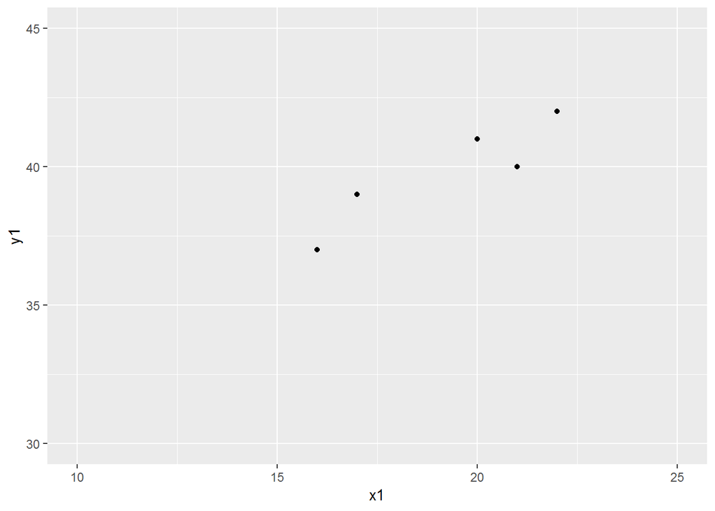

```r
punkty1 <- data.frame(id1=1:5,
                    x1=c(21,20,22,17,16),
                    y1=c(40,41,42,39,37))

ggplot(punkty1, aes(x1, y1)) + geom_point() + xlim(10,25) + ylim(30,45)
```

Tworzymy wszystkie możliwe pary punktów, których jest $n(n-1)/2$.

```r
punkty2 <- data.frame(id2=1:5,
                    x2=c(21,20,22,17,16),
                    y2=c(40,41,42,39,37))

punkty <- expand.grid(id1=punkty1$id1, id2=punkty2$id2)

punkty <- punkty[punkty$id1!=punkty$id2,]

pary_punktow <- as.data.frame(unique(t(apply(punkty[,1:2], 1, sort))))
names(pary_punktow) <- names(punkty)

pary_punktow <- merge(pary_punktow, punkty1)
pary_punktow <- merge(pary_punktow, punkty2)

pary_punktow
```

```
##    id2 id1 x1 y1 x2 y2
## 1    2   1 21 40 20 41
## 2    3   1 21 40 22 42
## 3    3   2 20 41 22 42
## 4    4   1 21 40 17 39
## 5    4   3 22 42 17 39
## 6    4   2 20 41 17 39
## 7    5   2 20 41 16 37
## 8    5   1 21 40 16 37
## 9    5   3 22 42 16 37
## 10   5   4 17 39 16 37
```

Obliczamy wartości beta ($\beta_{ij}=\frac{y_i-y_j}{x_i-x_j}$) i wagi ($wij=(x_i-x_j)^2$) dla każdej pary oraz współczynnik beta dla wszystkich punktów ($\beta=\frac{\sum w_{ij}\beta_{ij}}{\sum w_{ij}}$).

```r
pary_punktow <- pary_punktow %>%
  mutate(b=(y1-y2)/(x1-x2),
         w=(x1-x2)^2)

beta <- sum(pary_punktow$w*pary_punktow$b)/sum(pary_punktow$w)
beta
```

```
## [1] 0.6791045
```

Porównajmy z regresją liniową

```r
lm(y1 ~ x1, data=punkty1)
```

```
##
## Call:
## lm(formula = y1 ~ x1, data = punkty1)
##
## Coefficients:
## (Intercept)           x1
##     26.7612       0.6791
```

Dokładnie ten sam wynik!

## Z wyrazem wolnym

Oszacowanie wartości globalnej liczby osób biorących udział w teście na podstawie modelu liniowego

### Bez wag z próby

```r
lm(api.stu ~ enroll, data=apistrat)
```

```
##
## Call:
## lm(formula = api.stu ~ enroll, data = apistrat)
##
## Coefficients:
## (Intercept)       enroll
##     10.9570       0.8144
```

### Z wagami z próby

```r
m1 <- svyglm(api.stu ~ enroll, schemat)
m1
```

```
## Stratified Independent Sampling design
## svydesign(id = ~1, strata = ~stype, weights = ~pw, data = apistrat,
##     fpc = ~fpc)
##
## Call:  svyglm(formula = api.stu ~ enroll, schemat)
##
## Coefficients:
## (Intercept)       enroll
##     13.3438       0.8145
##
## Degrees of Freedom: 199 Total (i.e. Null);  196 Residual
## Null Deviance:       27280000
## Residual Deviance: 1459000   AIC: 2374
```

W przypadku modelu funkcja predict wymaga, aby dane były w formie data.frame.

```r
dane <- data.frame(enroll=sum(apipop$enroll, na.rm = T))

predict(m1, newdata = dane, total = nrow(apipop))
```

```
##      link    SE
## 1 3187252 31072
```

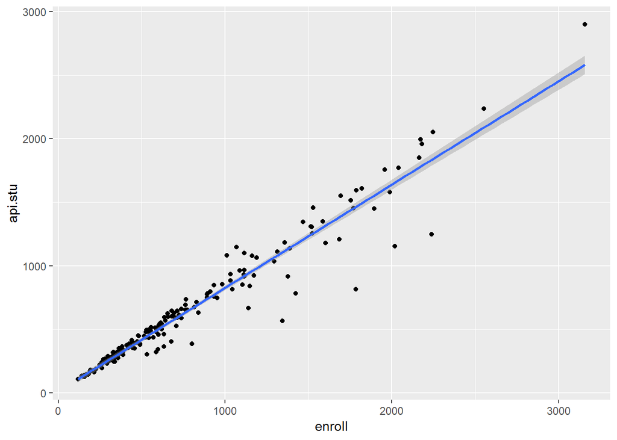

```r
ggplot(apistrat, aes(enroll, api.stu)) +
  geom_point() +
  geom_smooth(method="lm")
```

W modelu można także uwzględnić heteroskedastyczność wariancji

```r
m2 <- svyglm(api.stu ~ enroll, schemat, family=quasi(variance="mu"))
m2
```

```
## Stratified Independent Sampling design
## svydesign(id = ~1, strata = ~stype, weights = ~pw, data = apistrat,
##     fpc = ~fpc)
##
## Call:  svyglm(formula = api.stu ~ enroll, schemat, family = quasi(variance = "mu"))
##
## Coefficients:
## (Intercept)       enroll
##     12.9802       0.8152
##
## Degrees of Freedom: 199 Total (i.e. Null);  196 Residual
## Null Deviance:       41640
## Residual Deviance: 1563  AIC: NA
```

```r
predict(m2, newdata = dane, total = nrow(apipop))
```

```
##      link    SE
## 1 3187328 30574
```

### Zadanie (10 minut)

Proszę powtórzyć powyższy tok obliczeń dla zmiennej English Language Learners (ell). Czy zastosowanie modelu poprawia precyzję oszacowania?

```r
m3 <- svyglm(ell ~ enroll, schemat)
summary(m3)
```

```
##
## Call:
## svyglm(formula = ell ~ enroll, schemat)
##
## Survey design:
## svydesign(id = ~1, strata = ~stype, weights = ~pw, data = apistrat,
##     fpc = ~fpc)
##
## Coefficients:
##               Estimate Std. Error t value Pr(>|t|)
## (Intercept)  2.291e+01  2.550e+00   8.982   <2e-16 ***
## enroll      -7.131e-05  2.443e-03  -0.029    0.977
## ---
## Signif. codes:  0 '***' 0.001 '**' 0.01 '*' 0.05 '.' 0.1 ' ' 1
##
## (Dispersion parameter for gaussian family taken to be 452.2713)
##
## Number of Fisher Scoring iterations: 2
```

W przypadku modelu funkcja predict wymaga, aby dane były w formie data.frame.

```r
predict(m3, newdata = dane, total = nrow(apipop))
```

```
##     link    SE
## 1 141609 10283
```

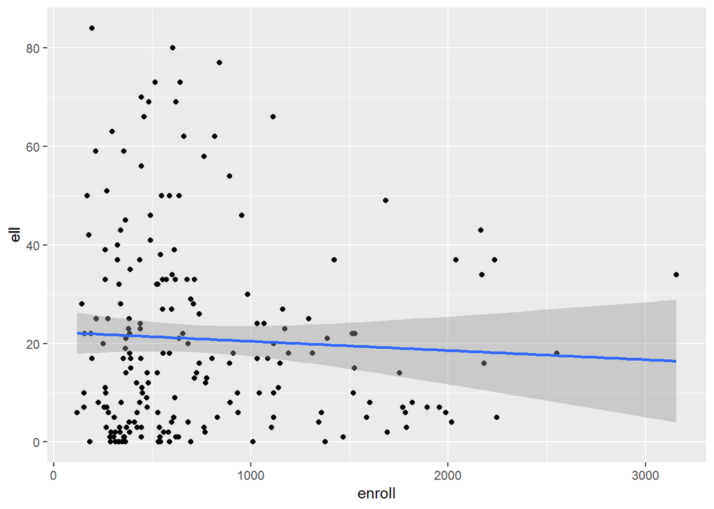

```r
ggplot(apistrat, aes(enroll, ell)) +
  geom_point() +
  geom_smooth(method="lm")
```